# String Parsing - KMP

**[KMP pattern matching algorithm] – O(N+M)**

- The idea is we can memorize what we have already seen by previous trial.

- So if we meet repeated string or charcter, we can skip it and jump to next character.

- To implement, we need Failure Function that records indices we have to go back from a current state when we encounter a mis-matched character.

- The Process of getting a Failure function is below.

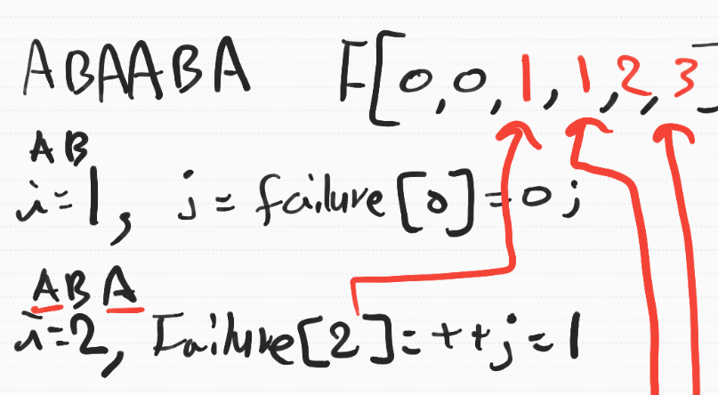

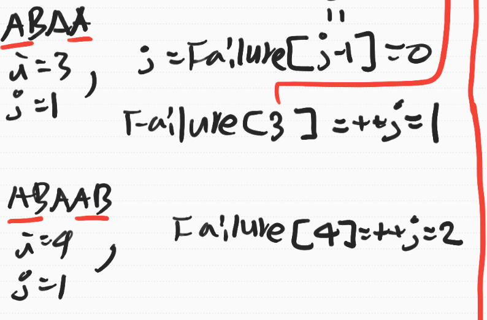

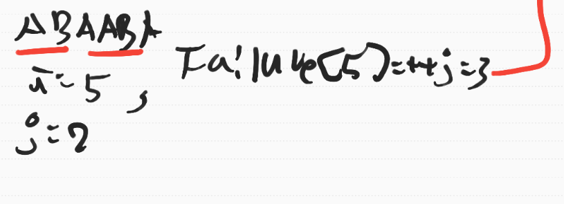

---{.cpp}

> void FindingFailure() {

> failure.assign(target.size(), 0);

> int j = 0;

> for (int i = 1; i < target.size(); i++) {

> while (j > 0 && target[i] != target[j]) j = failure[j - 1];

> if (target[i] == target[j]) failure[i] = ++j; //(1)

> }

> }

---

- It’s an DP algorithm, we don’t need to check previous characters if we meet same character.

**- Actually, KMP Algorithm is almost same with the way to get failure function.**

- we just need to revise the Failure Function code to that when two characters are matched, like above comment (1), increasing index j by 1. And then, if we finish to check all the character in the target string, stopping the algorithm. **That’s it!**

- see the whole code.

---{.cpp}

#include<iostream>

#include<vector>

using namespace std;

vector<int> failure;

string base = "DEWDQSDABDEFDDBBCCDABCDEASD";

string target = "ABCF";

void FindingFailure() {

failure.assign(target.size(), 0);

int j = 0;

for (int i = 1; i < target.size(); i++) {

while (j > 0 && target[i] != target[j]) j = failure[j - 1];

if (target[i] == target[j]) failure[i] = ++j;

}

}

bool KMP() {

int j = 0;

for (int i = 0; i < base.size(); i++) {

while (j > 0 && base[i] != target[j]) j = failure[j - 1];

if (base[i] == target[j]) {

if (j == target.size() - 1) {

return true;

}

else j++;

}

}

return false;

}

int main() {

ios_base::sync_with_stdio(false);

cin.tie(NULL); cout.tie(NULL);

FindingFailure();

cout << KMP();

return 0;

}

---